# Сравнение средних двух совокупностей с помощью t-критерия

Заходякин Г.В., postlogist@gmail.com

23.01.2017

## Введение

[Имитационное моделирование](http://www.anylogic.ru/case-studies) - это мощный инструмент анализа и улучшения процессов и систем. Имитационная модель - это компьютерная программа, которая передает наиболее важные для принятия решения аспекты поведения изучаемой системы. После разработки такой модели и проверки ее на адекватность, аналитик может изменять входные параметры модели, так чтобы добиться желаемого результата. Поскольку в имитационном моделировании практически всегда используются стохастические факторы, наблюдаемые выходные показатели модели также являются не константами, а случайными величинами. Распределения этих случайных величин и числовые характеристики данных распределений представляют интерес для аналитика. Сравнивая, как изменяются эти распределения при изменении входных параметров, аналитик принимает решение о том, какое сочетание параметров является наилучшим. Для обработки результатов имитационного эксперимента необходимо применять методы статистики.

В этом примере мы сравним два сценария (варианта организации бизнес-процессов в контакт-центре). Сценарии отличаются количеством операторов, работающих в часы пиковой нагрузки. Для сравнения сценариев используется показатель совокупных затрат в неделю.

На графике показаны распределения еженедельных затрат для базового и оптимизированного сценариев, полученные при многократном повторении (репликации) модельного эксперимента.

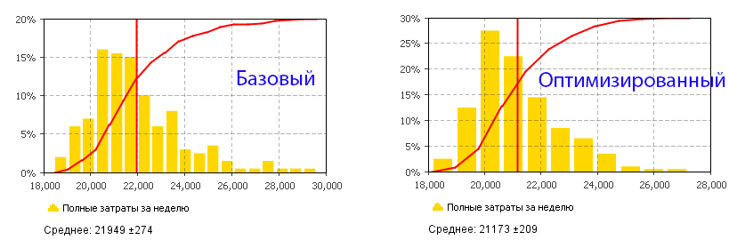

Сравнение сценариев

В базовом сценарии контакт-центр работает с текущей численностью операторов. В оптимизированном сценарии добавлено несколько операторов для обработки входящих звонков. Значения параметров подбирались с помощью оптимизатора OptQuest.

Можно видеть, что средние затраты для оптимизированного сценария примерно на 780 у.е. ниже, чем базовом сценарии. Но также можно видеть, что распределения значений затрат в различных репликациях довольно широкие и их области перекрываются. Чтобы доказать статистическую значимость (не случайность) результатов необходимо применить подходящий статистический метод. Для сравнения средних двух совокупностей можно применить двухвыборочный t-критерий.

**Примечание:** графики и наборы данных для анализа в этом примере были получены в разных прогонах модельного эксперимента, поэтому числовые характеристики будут немного отличаться.

## Подготовка

```r
suppressMessages(library(readr)) # считывание данных из текстовых файлов
suppressMessages(library(tidyverse)) # манипулирование данными
suppressMessages(library(ggplot2)) # визуализация
suppressMessages(library(scales)) # Процентный формат для осей графиков
```

Результаты эксперимента сохранены в двух файлах, находящихся в папке `data`: callcenter_basecase.txt и callcenter_optimized.txt

Данные сохранены в “плоском” табличном формате. Разделителями столбцов являются табуляции. Десятичный разделитель - точка. Первая строка содержит заголовки столбцов. Для считывания данных из текстовых файлов можно воспользоваться либо встроенными функциями: `read.table()`, `read.csv()` (в этом семействе несколько функций для разных форматов), либо аналогичными функциями из пакета `readr`. Функции из пакета `readr` работают быстрее и в сложных случаях дают больше возможностей для настройки формата данных. Изучить их подробнее можно в разделе [Data Import](http://r4ds.had.co.nz/data-import.html) книги R for Data Science.

```r
data_basecase <- read_tsv('data/callcenter_basecase.txt')
data_optimized <- read_tsv('data/callcenter_optimized.txt')
```

Файлы содержат параметры: число телефонных линий, а также число дополнительных сотрудников в пиковые часы. Две последние колонки - это еженедельные затраты и доля отклоненных звонков. В файлах содержится соответственно 200 и 200 наблюдений.

```r
glimpse(data_optimized)
```

```
## Observations: 200
## Variables: 9
## $ Scenario  <chr> "Optimized", "Optimized", "Optimized", "Optimized", ...
## $ nLines    <dbl> 26, 26, 26, 26, 26, 26, 26, 26, 26, 26, 26, 26, 26, ...
## $ nTechs1   <dbl> 1, 1, 1, 1, 1, 1, 1, 1, 1, 1, 1, 1, 1, 1, 1, 1, 1, 1...
## $ nTechs2   <dbl> 1, 1, 1, 1, 1, 1, 1, 1, 1, 1, 1, 1, 1, 1, 1, 1, 1, 1...
## $ nTechs3   <dbl> 0, 0, 0, 0, 0, 0, 0, 0, 0, 0, 0, 0, 0, 0, 0, 0, 0, 0...
## $ nTechs123 <dbl> 2, 2, 2, 2, 2, 2, 2, 2, 2, 2, 2, 2, 2, 2, 2, 2, 2, 2...
## $ nSalesmen <dbl> 2, 2, 2, 2, 2, 2, 2, 2, 2, 2, 2, 2, 2, 2, 2, 2, 2, 2...
## $ Cost      <dbl> 22703.75, 21003.85, 20192.79, 21321.26, 19350.71, 24...
## $ Rejected  <dbl> 0.07285714, 0.03318903, 0.03292181, 0.04341927, 0.03...
```

## Разведочный анализ

Для визуального анализа данных с помощью `ggplot2` удобно слить два набора данных в одну таблицу.

```r
data_merged <- union_all(data_basecase, data_optimized)
```

Сравним распределения затрат и доли отклоненных звонков в двух сценариях.

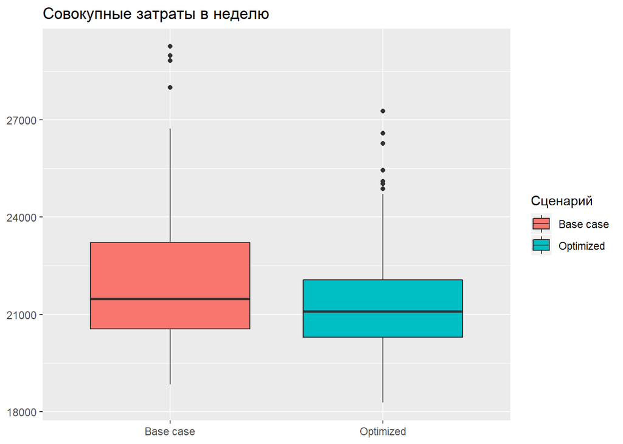

```r
# Затраты
ggplot(data = data_merged, aes(y = Cost, x = Scenario, fill = Scenario)) +
  geom_boxplot() +
  labs(title = 'Совокупные затраты в неделю', x = NULL, y = NULL, fill = 'Сценарий')
```

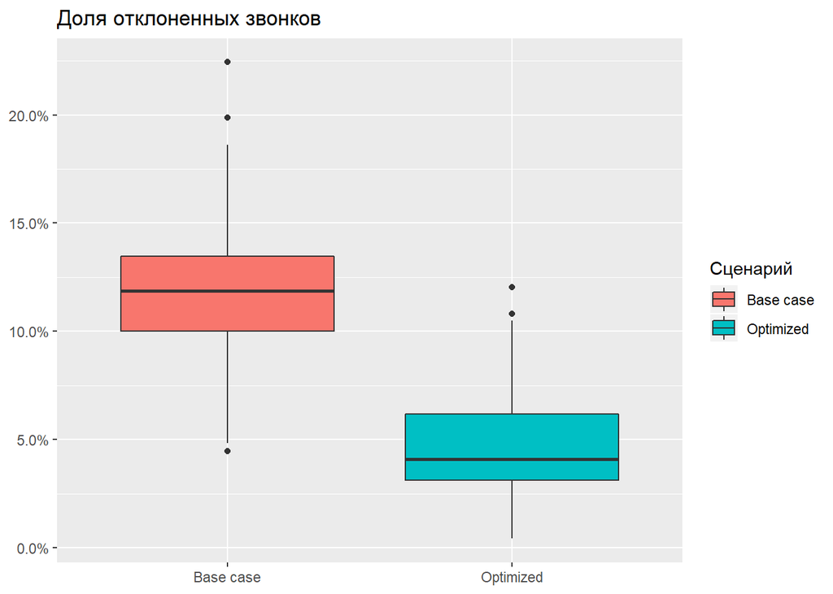

```r
# Доля отклоненных звонков
ggplot(data = data_merged, aes(y = Rejected, x = Scenario, fill = Scenario)) +
  geom_boxplot() +
  labs(title = 'Доля отклоненных звонков', x = NULL, y = NULL, fill = 'Сценарий') +
  scale_y_continuous(labels = percent)
```

На ящичной диаграмме видно, что медианная доля отклоненных звонков в оптимизированном сценарии почти в 3 раза ниже, чем базовом. Затраты отличаются не столь существенно.

Сравним средние значения двух совокупностей с учетом погрешности их оценки. Для этого можно воспользоваться встроенной функциональностью `ggplot2` для построения доверительных интервалов.

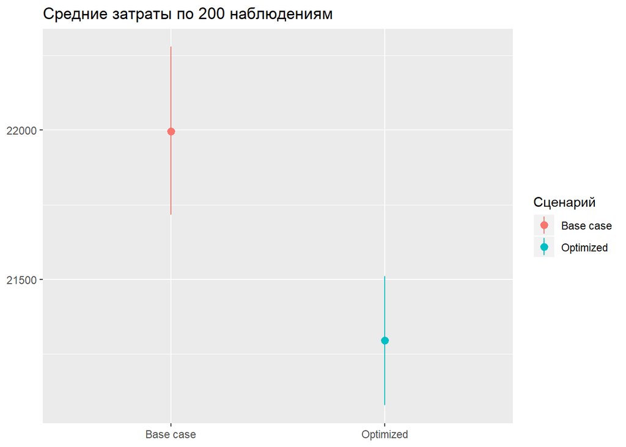

```r
ggplot(data = data_merged, aes(x = Scenario, y = Cost, color = Scenario)) +
  stat_summary(fun.data=mean_cl_boot) +
  labs(title = paste('Средние затраты по',
                nrow(data_basecase), 'наблюдениям' ),
       x = NULL, y = NULL, color = 'Сценарий')
```

Доверительные интервалы не пересекаются. Это означает, что данных достаточно для доказательства различия в средних значениях совокупностей, из которых взяты наши выборки. Подтвердить это различие можно при помощи двухвыборочного t-критерия.

## Проверка статистических гипотез

Наблюдения, которыми мы располагаем, принадлежат одной из двух совокупностей:

- *Все результаты прогонов модели с исходными параметрами* и
- *Все результаты прогонов модели с оптимизированными параметрами*.

**Нулевая гипотеза:** *Средние затраты в неделю одинаковы для двух совокупностей* (нет отличий между ними, разность средних равна нулю). **Альтернативная гипотеза:** *Средние затраты в неделю отличаются для двух совокупностей* (разность средних для двух совокупностей отлична от 0).

Для применения t-критерия в R есть встроенная функция: `t.test()`, которая реализует оба варианта критерия - для парных и для независимых выборок.

```r
result <- t.test(Cost ~ Scenario, data = data_merged)
result
```

```
##
##  Welch Two Sample t-test
##
## data:  Cost by Scenario
## t = 3.8387, df = 370.88, p-value = 0.0001454
## alternative hypothesis: true difference in means is not equal to 0
## 95 percent confidence interval:
##   341.6767 1059.3680
## sample estimates:
## mean in group Base case mean in group Optimized
##                21996.07                21295.54
```

В этом примере использована запись критерия в виде **формулы**: запись `Cost ~ Scenario` означает: *Затраты в зависимости от сценария*.

Левая часть формулы (до тильды) содержит зависимую переменную (`Cost`), а правая часть - факторы, влияющие на эту переменную (`Scenario`).

Столь низкая вероятность получения наблюдаемого отличия средних позволяет отвергнуть нулевую гипотезу в пользу альтернативной.

Наблюдаемая разность средних: 701 - не случайна. Она статистически значима. Оптимизированный сценарий позволяет снизить затраты.

В выводе функции `t.test()` также содержится интервальная оценка для разности средних двух совокупностей (342, 1059).

С практической точки зрения, достигнутое снижение затрат в 701 долларов позволит компании сэкономить в год около 36 тысяч долларов.